# Personal Regression Application

```r
library(tidyverse)
```

```r
library(mosaic)
library(janitor)

dat <- read_csv("health_data.csv")
dat <- clean_names(dat) %>%
  adorn_rounding(digits = 3, rounding = "half to even") %>%
  select(active_calories_kcal, distance_mi, flights_climbed_count, heart_rate_count_min, resting_calories_kcal) %>%
  filter(active_calories_kcal, distance_mi, flights_climbed_count, heart_rate_count_min, resting_calories_kcal >= 0 )
```

### Pairs Plot and Model Testing

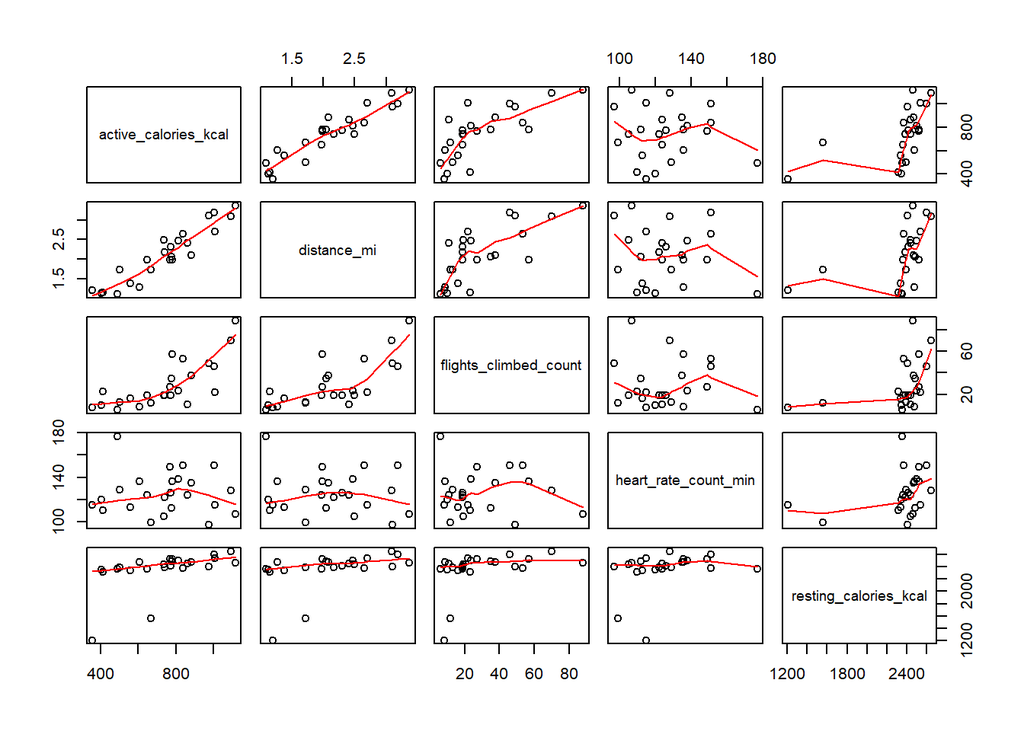

```r
pairs(dat, panel = panel.smooth)
```

```r
model <- lm(active_calories_kcal ~ distance_mi, data = dat)
summary(model)
```

```
##
## Call:
## lm(formula = active_calories_kcal ~ distance_mi, data = dat)
##
## Residuals:
##      Min       1Q   Median       3Q      Max
## -127.818  -53.630   -5.618   56.098  146.578
##
## Coefficients:
##             Estimate Std. Error t value Pr(>|t|)
## (Intercept)   125.35      51.21   2.448   0.0228 *
## distance_mi   291.83      23.08  12.645 1.45e-11 ***
## ---
## Signif. codes:  0 '***' 0.001 '**' 0.01 '*' 0.05 '.' 0.1 ' ' 1
##
## Residual standard error: 76.76 on 22 degrees of freedom
## Multiple R-squared:  0.879,  Adjusted R-squared:  0.8735
## F-statistic: 159.9 on 1 and 22 DF,  p-value: 1.446e-11
```

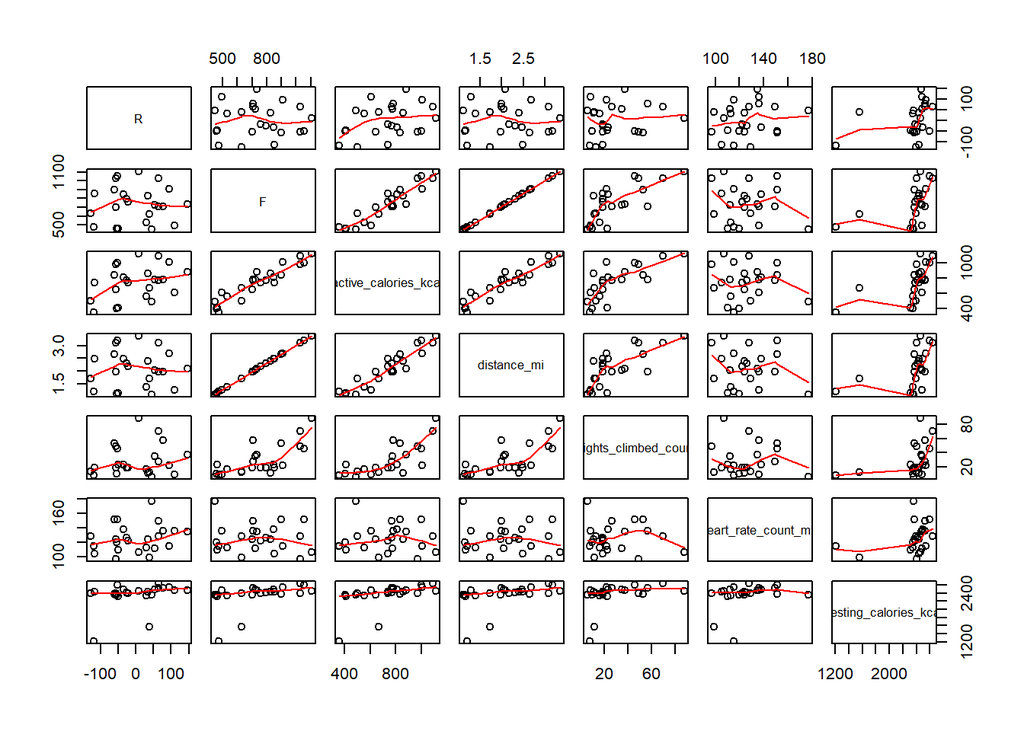

```r
#model2 <- lm(active_calories_kcal ~ flights_climbed_count, data = dat)
#summary(model2)

pairs(cbind(R=model$res, F = model$fit, dat), panel = panel.smooth)
```

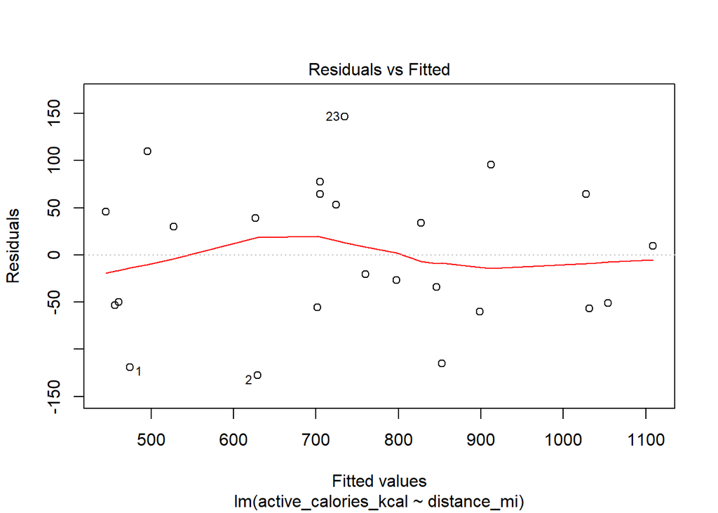

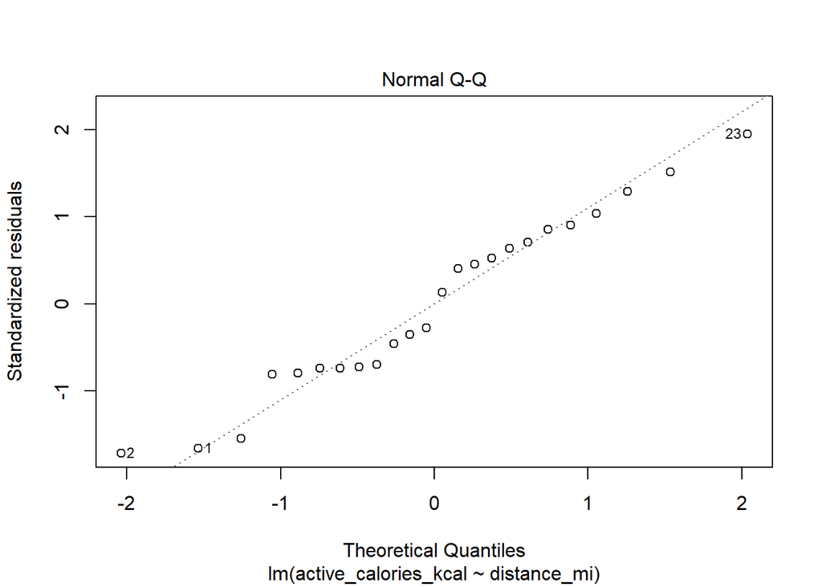

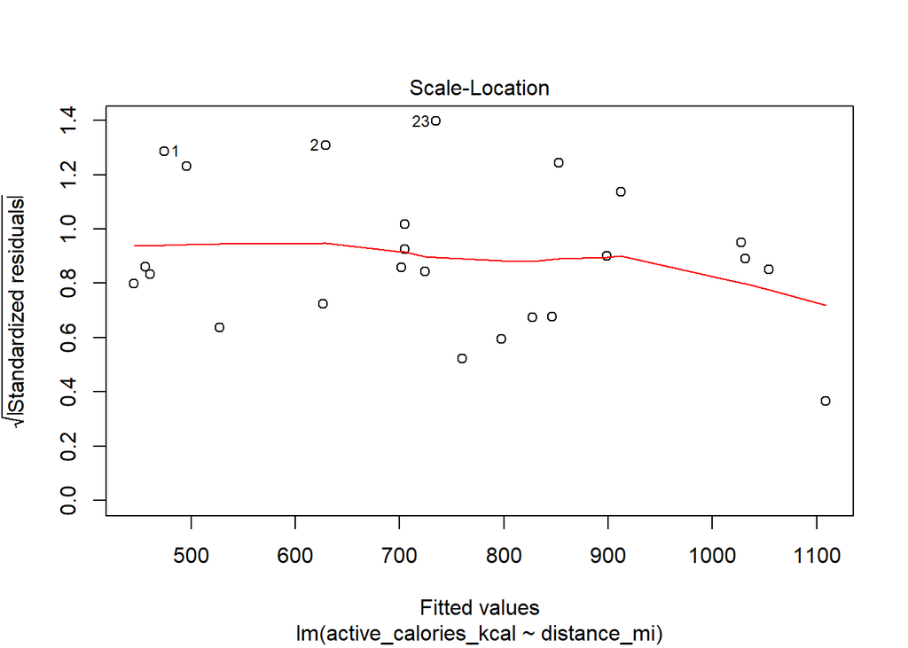

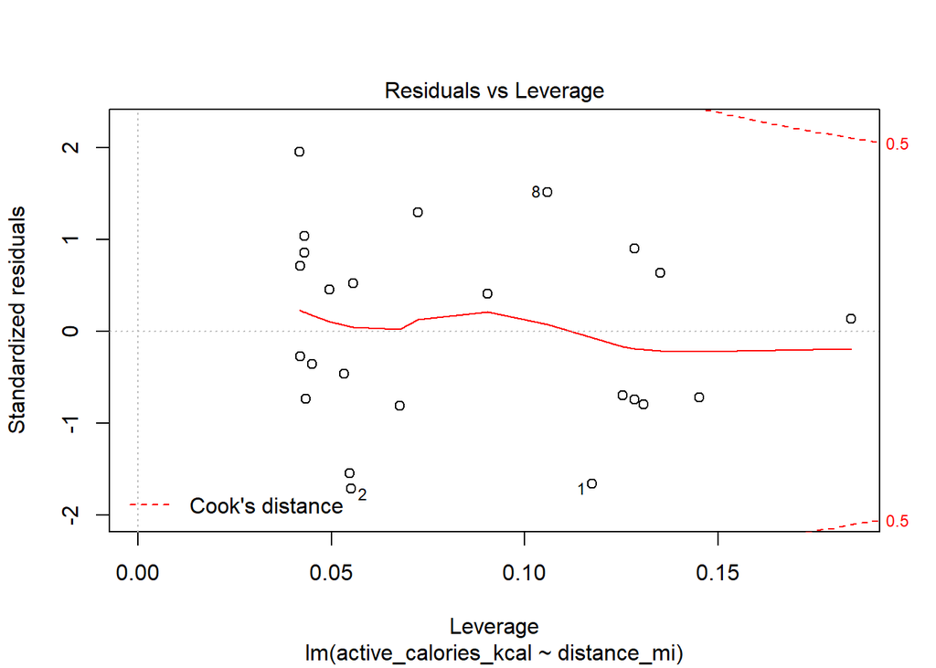

```r
plot(model)
```

After looking at the pairs plot and the summary table of the model I have elected that the best model that fits this data is the model with the Y as the Active Calories on the Distance in Miles. Now that I have found the right model I want to predict how many calories I will burn if I walk 2 miles a day

```r
predict(model, data.frame(distance_mi = 2), interval = "prediction", level = 0.95)
```

```
##        fit      lwr      upr
## 1 709.0076 546.4507 871.5646
```

Based on the prediction I will burn about 709.0076 calories at 2 miles a day but with a max of 871.56 and a low of 546.45 calories at 2 miles a day.

## Instructions

1. Use regression to help you find meaningful insights about your own life.
   - You could study your spending and earning habits.
   - You could consider your health habits as recorded by your phone or other electronic gadget.
   - You could consider the impacts of social media usage measured by number of posts, time spent, or words written, compared to your success in school each semester.
   - You could weigh your future job opportunities, graduate school, or other options against each other to find a “best choice” for you.
   - You could even take a second attempt at the Project 3 analysis, and follow up with more detail that better reflects your actual vehicle scenario. This would have to differ rather significantly from Project 3 though.
2. Your work should show breadth and depth of knowledge in the things we have learned this semester.

## Grading

1. Breadth of Knowledge {10} Points
   - What percentage of regression concepts from this semester does your analysis demonstrate?
2. Depth of Knowledge {10} Points
   - Does your analysis show great expertise in at least a few of the regression topics we have covered this semester? Specifically, you need to demonstrate good ability with: the mathematical model statement, hypothesis testing, confidence or prediction intervals, and transformations.